# Reproducible Research Project 1

Loading and preprocessing the data

1. Load the data set into R

```r
activity <- read.csv("activity.csv")
```

2. Convert the date field

```r
activity$date <- as.Date(activity$date)
```

What is the mean total number of step taken per day?

1.Calculate the total number of steps taken per day

```r
steps_per_day <- aggregate(steps ~ date, activity, sum)
```

2. Make a histogram of the total number of steps taken each day.

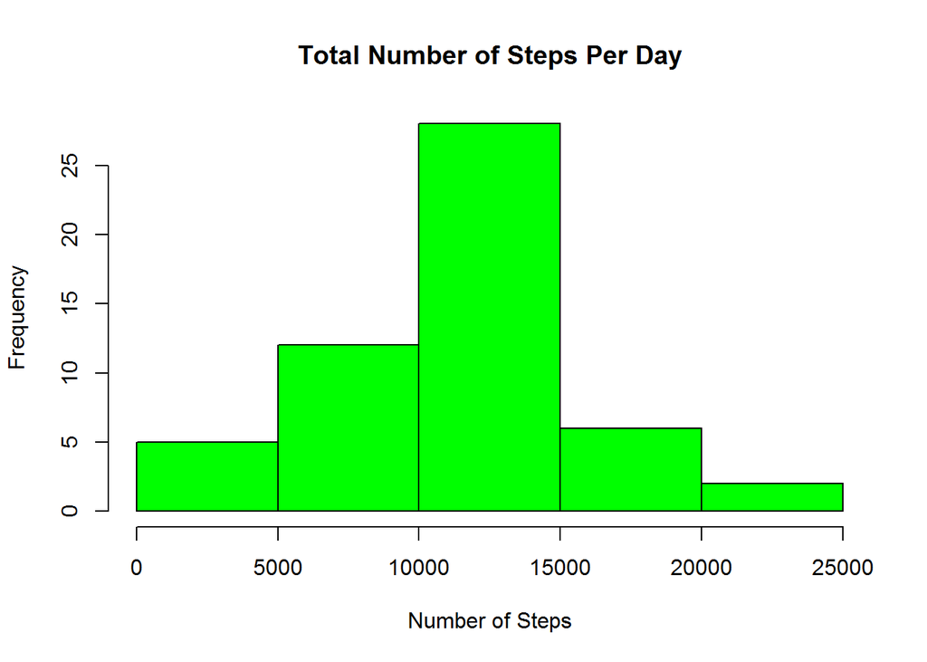

```r
hist(steps_per_day$steps, main = paste("Total Number of Steps Per Day"), col="green", xlab="Number of Steps")
```

3. Calculate and report the mean and median of the total number of steps taken per day.

```r
rmean <- mean(steps_per_day$steps)
rmedian <- median(steps_per_day$steps)
```

The mean steps taken per day were 10,766. The median steps taken per day were 10,765.

What is the average daily activity pattern?

1. Make a plot of the 5-minute interval and the average number of steps taken, averaged across all the days.

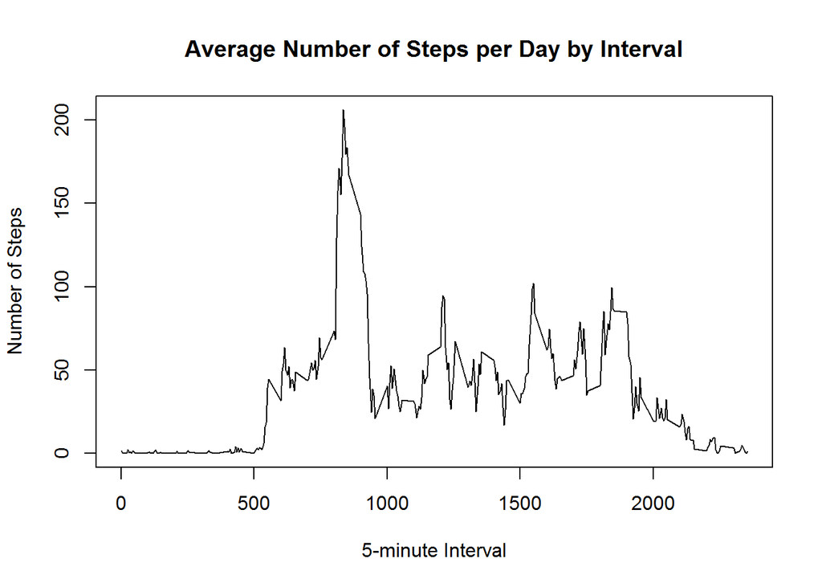

```r
steps_by_interval <- aggregate(steps ~ interval, activity, mean)
plot(steps_by_interval$interval,steps_by_interval$steps, type="l", xlab="5-minute Interval", ylab="Number of Steps", main="Average Number of Steps per Day by Interval")
```

2. Which 5-minute interval contains the maximum number of steps?

```r
max_interval <- steps_by_interval[which.max(steps_by_interval$steps),1]
```

The 835th 5-minute interval contains the maximum number of steps at 206.

Imputing missing values

1. Calculate and report the total number of missing values.

```r
missing_values <- sum(is.na(activity$steps))
```

There are 2304 missing values in the data set.

2. Devise a strategy for filling in the missing values.

The number of missing values in this dataset is fairly large, so we cannot determine if there is no bias. I will imput missing values based on the mean number of steps for a particular 5-minutes interval.

3. Create a new dataset that is equal to the original dataset but with the missing data filled in.

```r
activity2 <- transform(activity, steps = ifelse(is.na(activity$steps), steps_by_interval$steps[match(activity$interval, steps_by_interval$interval)], activity$steps))

activity2[as.character(activity2$date) == "2012-10-01", 1] <- 0
```

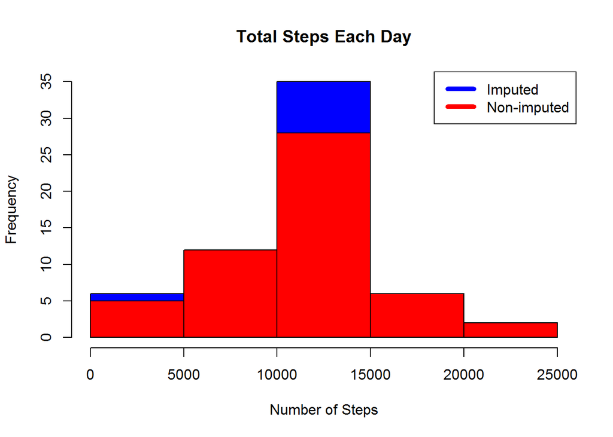

```r
steps_per_day2 <- aggregate(steps ~ date, activity2, sum)
hist(steps_per_day2$steps, main = paste("Total Steps Each Day"), col="blue", xlab="Number of Steps")

hist(steps_per_day$steps, main = paste("Total Steps Each Day"), col="red", xlab="Number of Steps", add=T)
legend("topright", c("Imputed", "Non-imputed"), col=c("blue", "red"), lwd=5)
```

```r
rmean2 <- mean(steps_per_day2$steps)
rmedian2 <- median(steps_per_day2$steps)
```

Are there differences in activity patterns between weekdays and weekends?

1. Create a new factor variable in the dataset with two levels - “weekday” and “weekend”.

```r
weekdays <- c("Monday", "Tuesday", "Wednesday", "Thursday",
              "Friday")
activity2$dow = as.factor(ifelse(is.element(weekdays(as.Date(activity2$date)),weekdays), "Weekday", "Weekend"))
```

2. Make a panel plot containing a time series of the 5-minute interval and the avg number of steps taken, averages across weekend or weekdays.

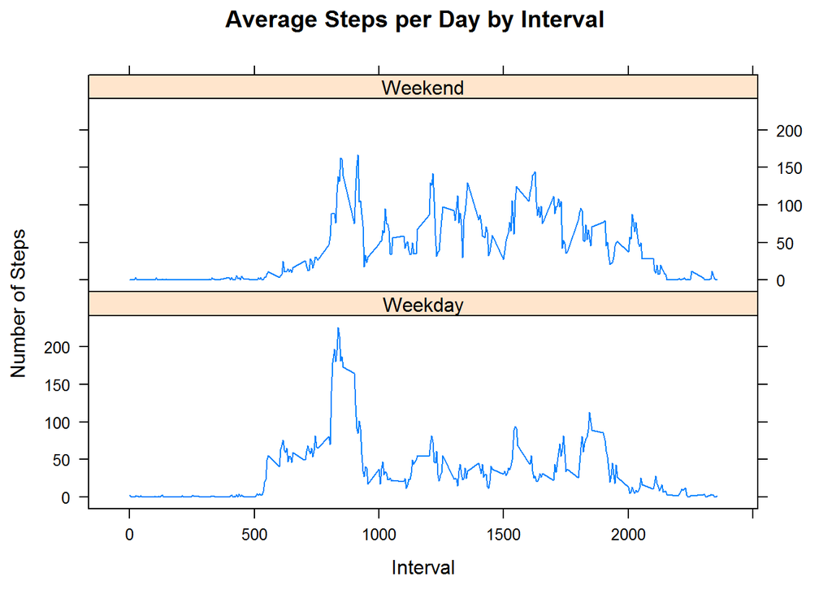

```r
steps_by_interval2 <- aggregate(steps ~ interval + dow, activity2, mean)
library(lattice)
xyplot(steps_by_interval2$steps ~ steps_by_interval2$interval|steps_by_interval2$dow, main="Average Steps per Day by Interval",xlab="Interval", ylab="Number of Steps",layout=c(1,2), type="l")
```